# Job_applications

2023-12-13

# Team Global project on Job Applicants Data

## 1. Import Libraries

```r
# Uncomment and run the below line to install the required packages
# install.packages(rpart.plot)
# install.packages(mltools)
# install.packages(data.table)
# install.packages(ggplot2)
# install.packages(tidyr)
# install.packages(dplyr)
# install.packages(ezids)
# install.packages(gganimate)
# install.packages(png)
# install.packages(gifski)
# install.packages(pROC)
# install.packages(MLmetrics)
# install.packages(rpart)
# install.packages(class)
# install.packages(e1071)
# install.packages(ROCR)

library(rpart.plot)
library(mltools)
library(data.table)
library(ggplot2)
library(tidyr)
library(dplyr)
library(ezids)
library(gganimate)
library(png)
library(gifski)
library(pROC)
library(MLmetrics)
library(rpart)
library(class)
library(e1071)
library(ROCR)
```

## 2. Import Data

```r
df = data.frame(read.csv('stackoverflow_full.csv', header = TRUE))
xkabledplyhead(df, title = "Job Applicants Data")
```

Job Applicants Data

| Index | Age | Accessibility | EdLevel | Employment | Gender | MentalHealth | MainBranch | YearsCode | YearsCodePro | Country | PreviousSalary | HaveWorkedWith | ComputerSkills | Employed |
| --- | --- | --- | --- | --- | --- | --- | --- | --- | --- | --- | --- | --- | --- | --- |
| 0 | <35 | No | Master | 1 | Man | No | Dev | 7 | 4 | Sweden | 51552 | C++;Python;Git;PostgreSQL | 4 | 0 |
| 1 | <35 | No | Undergraduate | 1 | Man | No | Dev | 12 | 5 | Spain | 46482 | Bash/Shell;HTML/CSS;JavaScript;Node.js;SQL;TypeScript;Git;Express;React.js;Vue.js;AWS;PostgreSQL | 12 | 1 |
| 2 | <35 | No | Master | 1 | Man | No | Dev | 15 | 6 | Germany | 77290 | C;C++;Java;Perl;Ruby;Git;Ruby on Rails | 7 | 0 |
| 3 | <35 | No | Undergraduate | 1 | Man | No | Dev | 9 | 6 | Canada | 46135 | Bash/Shell;HTML/CSS;JavaScript;PHP;Ruby;SQL;Git;jQuery;Laravel;Ruby on Rails;AWS;MySQL;PostgreSQL | 13 | 0 |
| 4 | >35 | No | PhD | 0 | Man | No | NotDev | 40 | 30 | Singapore | 160932 | C++;Python | 2 | 0 |

```r
# Structure of a data frame
str(df)
```

```
## 'data.frame':    73462 obs. of  15 variables:
##  $ Index         : int  0 1 2 3 4 5 6 7 8 9 ...
##  $ Age           : chr  "<35" "<35" "<35" "<35" ...
##  $ Accessibility : chr  "No" "No" "No" "No" ...
##  $ EdLevel       : chr  "Master" "Undergraduate" "Master" "Undergraduate" ...
##  $ Employment    : int  1 1 1 1 0 1 1 1 1 1 ...
##  $ Gender        : chr  "Man" "Man" "Man" "Man" ...
##  $ MentalHealth  : chr  "No" "No" "No" "No" ...
##  $ MainBranch    : chr  "Dev" "Dev" "Dev" "Dev" ...
##  $ YearsCode     : int  7 12 15 9 40 9 26 14 39 20 ...
##  $ YearsCodePro  : int  4 5 6 6 30 2 18 5 21 16 ...
##  $ Country       : chr  "Sweden" "Spain" "Germany" "Canada" ...
##  $ PreviousSalary: int  51552 46482 77290 46135 160932 38915 77831 81319 68507 37752 ...
##  $ HaveWorkedWith: chr  "C++;Python;Git;PostgreSQL" "Bash/Shell;HTML/CSS;JavaScript;Node.js;SQL;TypeScript;Git;Express;React.js;Vue.js;AWS;PostgreSQL" "C;C++;Java;Perl;Ruby;Git;Ruby on Rails" "Bash/Shell;HTML/CSS;JavaScript;PHP;Ruby;SQL;Git;jQuery;Laravel;Ruby on Rails;AWS;MySQL;PostgreSQL" ...
##  $ ComputerSkills: int  4 12 7 13 2 5 17 4 3 6 ...
##  $ Employed      : int  0 1 0 0 0 0 1 0 0 0 ...
```

## 3. Data preprocessing & Cleaning

Let’s first check for missing values and duplicate values if any.

```r
# Check for the number of missing values in each column
print(colSums(is.na(df)))
```

```
##          Index            Age  Accessibility        EdLevel     Employment
##              0              0              0              0              0
##         Gender   MentalHealth     MainBranch      YearsCode   YearsCodePro
##              0              0              0              0              0
##        Country PreviousSalary HaveWorkedWith ComputerSkills       Employed
##              0              0              0              0              0
```

```r
# Check duplicates
length(df$Index) - length(unique(df$Index))
```

```
## [1] 0
```

We notice that there are no missing values and duplicates in the data. Now, let us do some cleaning and feature engineering. First we’ll extract the numeric columns.

```r
# Extract the numeric columns
head(subset(df, select = c(names(df)[sapply(df, is.numeric)])))
```

```
##   Index Employment YearsCode YearsCodePro PreviousSalary ComputerSkills
## 1     0          1         7            4          51552              4
## 2     1          1        12            5          46482             12
## 3     2          1        15            6          77290              7
## 4     3          1         9            6          46135             13
## 5     4          0        40           30         160932              2
## 6     5          1         9            2          38915              5
##   Employed
## 1        0
## 2        1
## 3        0
## 4        0
## 5        0
## 6        0
```

```r
df_clean <- subset(df, select = -c(Index))
df_clean$Employment = as.character(df_clean$Employment)
df_clean$Employment[df_clean$Employment == "1"] <- "currently_employed"
df_clean$Employment[df_clean$Employment=="0"] <- "not_currently_employed"
df_clean$Employment = factor(df_clean$Employment)
df_clean$Employed = as.character(df_clean$Employed)
df_clean$Employed[df_clean$Employed == "1"] <- "hired"
df_clean$Employed[df_clean$Employed == "0"] <- "not_hired"
df_clean$Employed = factor(df_clean$Employed)
str(df_clean)
```

```
## 'data.frame':    73462 obs. of  14 variables:
##  $ Age           : chr  "<35" "<35" "<35" "<35" ...
##  $ Accessibility : chr  "No" "No" "No" "No" ...
##  $ EdLevel       : chr  "Master" "Undergraduate" "Master" "Undergraduate" ...
##  $ Employment    : Factor w/ 2 levels "currently_employed",..: 1 1 1 1 2 1 1 1 1 1 ...
##  $ Gender        : chr  "Man" "Man" "Man" "Man" ...
##  $ MentalHealth  : chr  "No" "No" "No" "No" ...
##  $ MainBranch    : chr  "Dev" "Dev" "Dev" "Dev" ...
##  $ YearsCode     : int  7 12 15 9 40 9 26 14 39 20 ...
##  $ YearsCodePro  : int  4 5 6 6 30 2 18 5 21 16 ...
##  $ Country       : chr  "Sweden" "Spain" "Germany" "Canada" ...
##  $ PreviousSalary: int  51552 46482 77290 46135 160932 38915 77831 81319 68507 37752 ...
##  $ HaveWorkedWith: chr  "C++;Python;Git;PostgreSQL" "Bash/Shell;HTML/CSS;JavaScript;Node.js;SQL;TypeScript;Git;Express;React.js;Vue.js;AWS;PostgreSQL" "C;C++;Java;Perl;Ruby;Git;Ruby on Rails" "Bash/Shell;HTML/CSS;JavaScript;PHP;Ruby;SQL;Git;jQuery;Laravel;Ruby on Rails;AWS;MySQL;PostgreSQL" ...
##  $ ComputerSkills: int  4 12 7 13 2 5 17 4 3 6 ...
##  $ Employed      : Factor w/ 2 levels "hired","not_hired": 2 1 2 2 2 2 1 2 2 2 ...
```

Now let’s take a look at the character columns.

```r
# Extract the character columns
head(subset(df_clean, select = c(names(df)[sapply(df, is.character)])))
```

```
##   Age Accessibility       EdLevel Gender MentalHealth MainBranch   Country
## 1 <35            No        Master    Man           No        Dev    Sweden
## 2 <35            No Undergraduate    Man           No        Dev     Spain
## 3 <35            No        Master    Man           No        Dev   Germany
## 4 <35            No Undergraduate    Man           No        Dev    Canada
## 5 >35            No           PhD    Man           No     NotDev Singapore
## 6 <35            No        Master    Man           No        Dev    France
##                                                                                      HaveWorkedWith
## 1                                                                         C++;Python;Git;PostgreSQL
## 2  Bash/Shell;HTML/CSS;JavaScript;Node.js;SQL;TypeScript;Git;Express;React.js;Vue.js;AWS;PostgreSQL
## 3                                                            C;C++;Java;Perl;Ruby;Git;Ruby on Rails
## 4 Bash/Shell;HTML/CSS;JavaScript;PHP;Ruby;SQL;Git;jQuery;Laravel;Ruby on Rails;AWS;MySQL;PostgreSQL
## 5                                                                                        C++;Python
## 6                                                                JavaScript;Python;Docker;Git;MySQL
```

```r
df_clean$Age = factor(df_clean$Age)
df_clean$Accessibility = factor(df_clean$Accessibility)
df_clean$EdLevel = factor(df_clean$EdLevel, ordered = T,
                          levels = c("Other", "NoHigherEd", "Undergraduate", "Master", "PhD"))
df_clean$Gender = factor(df_clean$Gender)
df_clean$MentalHealth = factor(df_clean$MentalHealth)
df_clean$MainBranch = factor(df_clean$MainBranch)
str(df_clean)
```

```
## 'data.frame':    73462 obs. of  14 variables:
##  $ Age           : Factor w/ 2 levels "<35",">35": 1 1 1 1 2 1 2 1 2 2 ...
##  $ Accessibility : Factor w/ 2 levels "No","Yes": 1 1 1 1 1 1 1 1 1 1 ...
##  $ EdLevel       : Ord.factor w/ 5 levels "Other"<"NoHigherEd"<..: 4 3 4 3 5 4 4 4 3 4 ...
##  $ Employment    : Factor w/ 2 levels "currently_employed",..: 1 1 1 1 2 1 1 1 1 1 ...
##  $ Gender        : Factor w/ 3 levels "Man","NonBinary",..: 1 1 1 1 1 1 1 1 1 1 ...
##  $ MentalHealth  : Factor w/ 2 levels "No","Yes": 1 1 1 1 1 1 1 1 1 1 ...
##  $ MainBranch    : Factor w/ 2 levels "Dev","NotDev": 1 1 1 1 2 1 1 2 1 1 ...
##  $ YearsCode     : int  7 12 15 9 40 9 26 14 39 20 ...
##  $ YearsCodePro  : int  4 5 6 6 30 2 18 5 21 16 ...
##  $ Country       : chr  "Sweden" "Spain" "Germany" "Canada" ...
##  $ PreviousSalary: int  51552 46482 77290 46135 160932 38915 77831 81319 68507 37752 ...
##  $ HaveWorkedWith: chr  "C++;Python;Git;PostgreSQL" "Bash/Shell;HTML/CSS;JavaScript;Node.js;SQL;TypeScript;Git;Express;React.js;Vue.js;AWS;PostgreSQL" "C;C++;Java;Perl;Ruby;Git;Ruby on Rails" "Bash/Shell;HTML/CSS;JavaScript;PHP;Ruby;SQL;Git;jQuery;Laravel;Ruby on Rails;AWS;MySQL;PostgreSQL" ...
##  $ ComputerSkills: int  4 12 7 13 2 5 17 4 3 6 ...
##  $ Employed      : Factor w/ 2 levels "hired","not_hired": 2 1 2 2 2 2 1 2 2 2 ...
```

We remove faulty data where their professional coding experience is more than their coding experience.

```r
nrow(subset(df_clean, subset = df_clean$YearsCode<df_clean$YearsCodePro))
```

```
## [1] 588
```

```r
df_clean = subset(df_clean, subset = df_clean$YearsCode>df_clean$YearsCodePro)
```

We observe 588 such records and remove them.

Let’s take a look at some plots and distribution in order to deal with outliers.

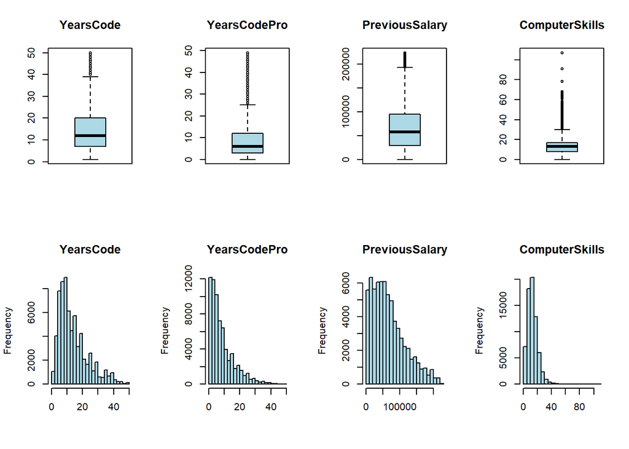

```r
# Create a list of the columns that we use in combined boxplot
columns_to_plot <- c("YearsCode", "YearsCodePro", "PreviousSalary", "ComputerSkills")

# Set up the plotting area to display all boxplots together
par(mfrow = c(2, length(columns_to_plot)))

# Display the boxplots
for (i in 1:length(columns_to_plot)) {
  boxplot(df_clean[[columns_to_plot[i]]], main = columns_to_plot[i],col = "lightblue")
}
for (i in 1:length(columns_to_plot)) {
  hist(df_clean[[columns_to_plot[i]]], main = columns_to_plot[i], xlab = element_blank(), col = "lightblue")
}
```

```r
# plotting area layout
par(mfrow = c(2, 1))
```

```r
o_code= quantile(df_clean$YearsCode, probs = 0.75, na.rm = FALSE) +
  (1.5 * IQR(df_clean$YearsCode))
o_procode = quantile(df_clean$YearsCodePro, probs = 0.75, na.rm = FALSE) +
  (1.5 * IQR(df_clean$YearsCodePro))
o_presal = quantile(df_clean$PreviousSalary, probs = 0.75, na.rm = FALSE) +
  (1.5 * IQR(df_clean$PreviousSalary))
o_cskill = quantile(df_clean$ComputerSkills, probs = 0.75, na.rm = FALSE) +
  (1.5 * IQR(df_clean$ComputerSkills))

print(paste(o_code, o_procode, o_presal, o_cskill))
```

```
## [1] "39.5 25.5 193596.875 30.5"
```

```r
df_clean = subset(df_clean, subset = df_clean$YearsCode < 40)
df_clean = subset(df_clean, subset = df_clean$YearsCodePro < 40)
df_clean = subset(df_clean, subset = df_clean$ComputerSkills < 35)
```

Lets take a look at the final data now:

```r
df_final <- df_clean
xkabledplyhead(df_final, title = "Final Data")
```

Final Data

|  | Age | Accessibility | EdLevel | Employment | Gender | MentalHealth | MainBranch | YearsCode | YearsCodePro | Country | PreviousSalary | HaveWorkedWith | ComputerSkills | Employed |
| --- | --- | --- | --- | --- | --- | --- | --- | --- | --- | --- | --- | --- | --- | --- |
| 1 | <35 | No | Master | currently_employed | Man | No | Dev | 7 | 4 | Sweden | 51552 | C++;Python;Git;PostgreSQL | 4 | not_hired |
| 2 | <35 | No | Undergraduate | currently_employed | Man | No | Dev | 12 | 5 | Spain | 46482 | Bash/Shell;HTML/CSS;JavaScript;Node.js;SQL;TypeScript;Git;Express;React.js;Vue.js;AWS;PostgreSQL | 12 | hired |
| 3 | <35 | No | Master | currently_employed | Man | No | Dev | 15 | 6 | Germany | 77290 | C;C++;Java;Perl;Ruby;Git;Ruby on Rails | 7 | not_hired |
| 4 | <35 | No | Undergraduate | currently_employed | Man | No | Dev | 9 | 6 | Canada | 46135 | Bash/Shell;HTML/CSS;JavaScript;PHP;Ruby;SQL;Git;jQuery;Laravel;Ruby on Rails;AWS;MySQL;PostgreSQL | 13 | not_hired |
| 6 | <35 | No | Master | currently_employed | Man | No | Dev | 9 | 2 | France | 38915 | JavaScript;Python;Docker;Git;MySQL | 5 | not_hired |

```r
# Getting the number of categorical and numerical columns
cat_cols <- colnames(subset(df_final, select = c(names(df_final)[(sapply(df_final, is.factor)) |
                                                       (sapply(df_final, is.ordered)) |
                                                       (sapply(df_final, is.character))])))

num_cols <- colnames(subset(df_final, select = c(names(df_final)[sapply(df_final, is.integer)])))

# Displaying the information
cat("Basic summary and Raw Counts for the Dataset:\n")
```

```
## Basic summary and Raw Counts for the Dataset:
```

```r
cat("Rows:", dim(df_final)[1], "\n")
```

```
## Rows: 65906
```

```r
cat("Columns:", dim(df_final)[2], "\n")
```

```
## Columns: 14
```

```r
cat("Numerical columns:", num_cols, "\n")
```

```
## Numerical columns: YearsCode YearsCodePro PreviousSalary ComputerSkills
```

```r
cat("Categorical Columns:", cat_cols, "\n")
```

```
## Categorical Columns: Age Accessibility EdLevel Employment Gender MentalHealth MainBranch Country HaveWorkedWith Employed
```

## 4. EDA

Let’s first try to get a good picture of the data which will act as the 1st step to answer the questions that we proposed.

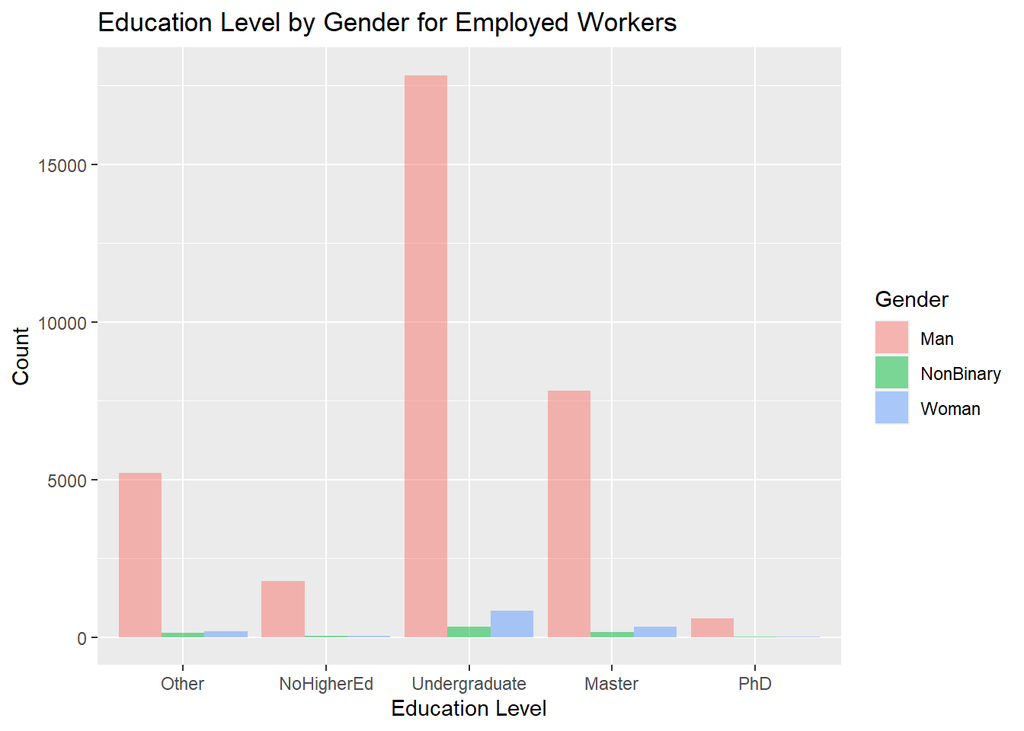

```r
ggplot(data = subset(df_final, subset = Employed=='hired'), aes(EdLevel, after_stat(count))) +
  geom_bar(aes(fill = Gender), position = 'dodge', alpha = 0.5) +
  labs(title = "Education Level by Gender for Employed Workers", x="Education Level", y="Count")
```

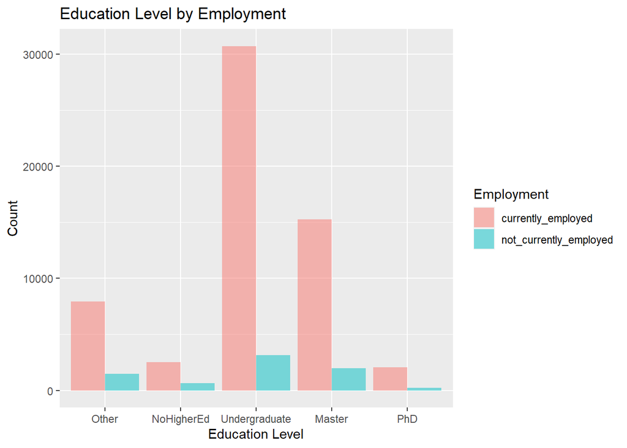

```r
ggplot(data = df_final, aes(EdLevel)) +
  geom_bar(aes(fill = Employment), position = 'dodge', alpha = 0.5) +
  labs(title = "Education Level by Employment", x="Education Level", y="Count")
```

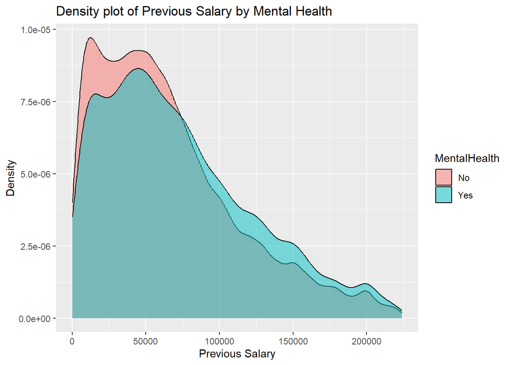

```r
ggplot(data = df_final, aes(x = PreviousSalary, fill = MentalHealth)) +
  geom_density(alpha = 0.5) +
  labs(title = "Density plot of Previous Salary by Mental Health", x="Previous Salary", y= 'Density')
```

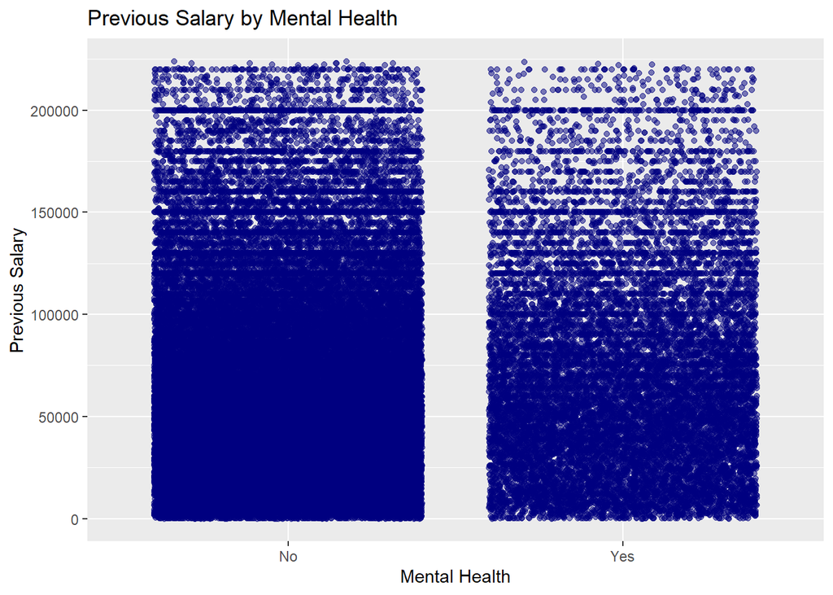

```r
ggplot(data = df_final, aes(x = MentalHealth, y = PreviousSalary)) +
  geom_jitter(alpha = 0.5, col = 'navy') +
  labs(title = "Previous Salary by Mental Health", x = 'Mental Health', y="Previous Salary")
```

## 5. Hypothesis Testing

We consistently use the standard alpha-level of .05 as a basis for making conclusions for our hypothesis tests.

### Test 1: Is there a significant difference between employed males and non-males in their respective education levels?

Bachelor’s degree:

```r
# We first subset into the different education levels, here undergraduate
undergrad <- subset(df_clean, df_clean$EdLevel == "Undergraduate")


# For the two sample z test, we need our two samples, males and nonmales
undergrad_male <- subset(undergrad, undergrad$Gender == "Man") # Sample 1, males

undergrad_male_employed <- subset(undergrad_male, undergrad_male$Employment == "currently_employed")

undergrad_nonmales <- subset(undergrad, undergrad$Gender != "Man") # Sample 2, females and nonbinary

undergrad_nonmales_employed <- (subset(undergrad_nonmales, undergrad_nonmales$Employment == "currently_employed"))


undergrad_employed_ztest <- prop.test(c(nrow(undergrad_male_employed), nrow(undergrad_nonmales_employed)), c(nrow(undergrad_male),nrow(undergrad_nonmales)))
undergrad_employed_ztest
```

```
##
##  2-sample test for equality of proportions with continuity correction
##
## data:  c(nrow(undergrad_male_employed), nrow(undergrad_nonmales_employed)) out of c(nrow(undergrad_male), nrow(undergrad_nonmales))
## X-squared = 1.0964, df = 1, p-value = 0.2951
## alternative hypothesis: two.sided
## 95 percent confidence interval:
##  -0.018869581  0.005340031
## sample estimates:
##    prop 1    prop 2
## 0.9071626 0.9139273
```

Master’s degree:

```r
# We first subset into the different education levels, here masters
masters <- subset(df_clean, df_clean$EdLevel == "Master")


# For the two sample z test, we need our two samples, males and nonmales
masters_male <- subset(masters, masters$Gender == "Man") # Sample 1, males

masters_male_employed <- subset(masters_male, masters_male$Employment == "currently_employed")


masters_nonmales <- subset(masters, undergrad$Gender != "Man") # Sample 2, females and nonbinary

masters_nonmales_employed <- (subset(masters_nonmales, masters_nonmales$Employment == "currently_employed"))


masters_employed_ztest <- prop.test(c(nrow(masters_male_employed), nrow(masters_nonmales_employed)), c(nrow(masters_male),nrow(masters_nonmales)))
masters_employed_ztest
```

```
##
##  2-sample test for equality of proportions with continuity correction
##
## data:  c(nrow(masters_male_employed), nrow(masters_nonmales_employed)) out of c(nrow(masters_male), nrow(masters_nonmales))
## X-squared = 2755.3, df = 1, p-value < 2.2e-16
## alternative hypothesis: two.sided
## 95 percent confidence interval:
##  0.4187530 0.4609501
## sample estimates:
##    prop 1    prop 2
## 0.8844882 0.4446367
```

PhD:

```r
# We first subset into the different education levels, here PhD
phd <- subset(df_clean, df_clean$EdLevel == "PhD")


# For the two sample z test, we need our two samples, males and nonmales
phd_male <- subset(phd, phd$Gender == "Man") # Sample 1, males

phd_male_employed <- subset(phd_male, phd_male$Employment == "currently_employed")

phd_nonmales <- subset(phd, phd$Gender != "Man") # Sample 2, females and nonbinary

phd_nonmales_employed <- (subset(phd_nonmales, phd_nonmales$Employment == "currently_employed"))


phd_employed_ztest <- prop.test(c(nrow(phd_male_employed), nrow(phd_nonmales_employed)), c(nrow(phd_male),nrow(phd_nonmales)))
phd_employed_ztest
```

```
##
##  2-sample test for equality of proportions with continuity correction
##
## data:  c(nrow(phd_male_employed), nrow(phd_nonmales_employed)) out of c(nrow(phd_male), nrow(phd_nonmales))
## X-squared = 0.1364, df = 1, p-value = 0.7119
## alternative hypothesis: two.sided
## 95 percent confidence interval:
##  -0.03799399  0.06073721
## sample estimates:
##    prop 1    prop 2
## 0.9063992 0.8950276
```

### Test 2: Does mental health influence previous salary?

```r
# Subset the PreviousSalary for individuals with 'Yes' and 'No' in the MentalHealth column
salary_yes <- df_clean$PreviousSalary[df_clean$MentalHealth == "Yes"]
salary_no <- df_clean$PreviousSalary[df_clean$MentalHealth == "No"]

# Checking the mean of both groups
format(mean(salary_yes, na.rm = TRUE), digits=5)
```

```
## [1] "72709"
```

```r
format(mean(salary_no, na.rm = TRUE), digits=5)
```

```
## [1] "64652"
```

```r
# Now we conduct a two-sample t-test on PreviousSalary between the two groups
ttest_2sample_salary_yes_no <- t.test(salary_yes, salary_no)
ttest_2sample_salary_yes_no
```

```
##
##  Welch Two Sample t-test
##
## data:  salary_yes and salary_no
## t = 17.244, df = 23058, p-value < 2.2e-16
## alternative hypothesis: true difference in means is not equal to 0
## 95 percent confidence interval:
##  7141.483 8973.164
## sample estimates:
## mean of x mean of y
##  72709.47  64652.15
```

## 6. Data Preparation

In preparation for model building, we want to check if the data types are accurate, encode categorical variables, scale any parameters if needed, perform feature engineering, and check for severe data imbalance.

```r
str(df_final)
```

```
## 'data.frame':    65906 obs. of  14 variables:
##  $ Age           : Factor w/ 2 levels "<35",">35": 1 1 1 1 1 2 1 2 2 1 ...
##  $ Accessibility : Factor w/ 2 levels "No","Yes": 1 1 1 1 1 1 1 1 1 1 ...
##  $ EdLevel       : Ord.factor w/ 5 levels "Other"<"NoHigherEd"<..: 4 3 4 3 4 4 4 3 4 3 ...
##  $ Employment    : Factor w/ 2 levels "currently_employed",..: 1 1 1 1 1 1 1 1 1 1 ...
##  $ Gender        : Factor w/ 3 levels "Man","NonBinary",..: 1 1 1 1 1 1 1 1 1 1 ...
##  $ MentalHealth  : Factor w/ 2 levels "No","Yes": 1 1 1 1 1 1 1 1 1 2 ...
##  $ MainBranch    : Factor w/ 2 levels "Dev","NotDev": 1 1 1 1 1 1 2 1 1 1 ...
##  $ YearsCode     : int  7 12 15 9 9 26 14 39 20 4 ...
##  $ YearsCodePro  : int  4 5 6 6 2 18 5 21 16 2 ...
##  $ Country       : chr  "Sweden" "Spain" "Germany" "Canada" ...
##  $ PreviousSalary: int  51552 46482 77290 46135 38915 77831 81319 68507 37752 122580 ...
##  $ HaveWorkedWith: chr  "C++;Python;Git;PostgreSQL" "Bash/Shell;HTML/CSS;JavaScript;Node.js;SQL;TypeScript;Git;Express;React.js;Vue.js;AWS;PostgreSQL" "C;C++;Java;Perl;Ruby;Git;Ruby on Rails" "Bash/Shell;HTML/CSS;JavaScript;PHP;Ruby;SQL;Git;jQuery;Laravel;Ruby on Rails;AWS;MySQL;PostgreSQL" ...
##  $ ComputerSkills: int  4 12 7 13 5 17 4 3 6 18 ...
##  $ Employed      : Factor w/ 2 levels "hired","not_hired": 2 1 2 2 2 1 2 2 2 1 ...
```

From our EDA section, we see that all variables have been converted to their correct, respective data types. Now, we will encode our categorical variables; namely `Age`, `Accessibility`, `EdLevel`, `Employment`, `Gender`, `MentalHealth`, and `MainBranch` (leaving “Country” as it is).

Since `Age` and `EdLevel` are ordinal variables, we use ordinal encoding to prepare this subset of categorical data.  
`Accessibility`, `Employment`, `MentalHealth`, `MainBranch` are nominal variables with just 2 categories within them, so we will label encode them.

```r
#saving df_final copy
df_enc = df_final

# We first want to set age as an ordinal factor:
df_enc$Age = factor(df_enc$Age, ordered = T,
                          levels = c("<35", ">35"))
# EdLevel was already converted to an ordinal variable in the EDA section so we can proceed

# Now we can conduct label encoding on Age and Education Level:
df_enc$Age <- as.numeric(df_enc$Age)
df_enc$EdLevel <- as.numeric(df_enc$EdLevel)
df_enc$Accessibility <- as.numeric(df_enc$Accessibility)
df_enc$Employment <- as.numeric(df_enc$Employment)
df_enc$MentalHealth <- as.numeric(df_enc$MentalHealth)
df_enc$MainBranch <- as.numeric(df_enc$MainBranch)
```

`Gender` has 3 categories and is nominal, so we will use the one-hot-encoding method.

```r
# subsetting the dataframe to select those cateogrical variables that require one hot encoding:
one_hot_df <- subset(df_enc, select = Gender)

#performing one hot encoding
one_hot_df <- one_hot(as.data.table(one_hot_df))

# saving the dataframe before one hot encoding:
df_before_oneHot <- df_enc

# dropping the categorical variables that we just performed one hot encoding on and adding the new columns:
drops <- "Gender"
df_enc <- df_enc[ , !(names(df_enc) %in% drops)]

df_enc <- cbind(df_enc, one_hot_df)
```

Removing`HaveWorkedWith` and `Country` columns.

```r
df_enc <- subset(df_enc, select = -c(HaveWorkedWith))
df_final2 <- subset(df_enc, select = -c(Country))
str(df_final2)
```

```
## 'data.frame':    65906 obs. of  14 variables:
##  $ Age             : num  1 1 1 1 1 2 1 2 2 1 ...
##  $ Accessibility   : num  1 1 1 1 1 1 1 1 1 1 ...
##  $ EdLevel         : num  4 3 4 3 4 4 4 3 4 3 ...
##  $ Employment      : num  1 1 1 1 1 1 1 1 1 1 ...
##  $ MentalHealth    : num  1 1 1 1 1 1 1 1 1 2 ...
##  $ MainBranch      : num  1 1 1 1 1 1 2 1 1 1 ...
##  $ YearsCode       : int  7 12 15 9 9 26 14 39 20 4 ...
##  $ YearsCodePro    : int  4 5 6 6 2 18 5 21 16 2 ...
##  $ PreviousSalary  : int  51552 46482 77290 46135 38915 77831 81319 68507 37752 122580 ...
##  $ ComputerSkills  : int  4 12 7 13 5 17 4 3 6 18 ...
##  $ Employed        : Factor w/ 2 levels "hired","not_hired": 2 1 2 2 2 1 2 2 2 1 ...
##  $ Gender_Man      : int  1 1 1 1 1 1 1 1 1 1 ...
##  $ Gender_NonBinary: int  0 0 0 0 0 0 0 0 0 0 ...
##  $ Gender_Woman    : int  0 0 0 0 0 0 0 0 0 0 ...
```

Let’s do a quick class imbalance check.

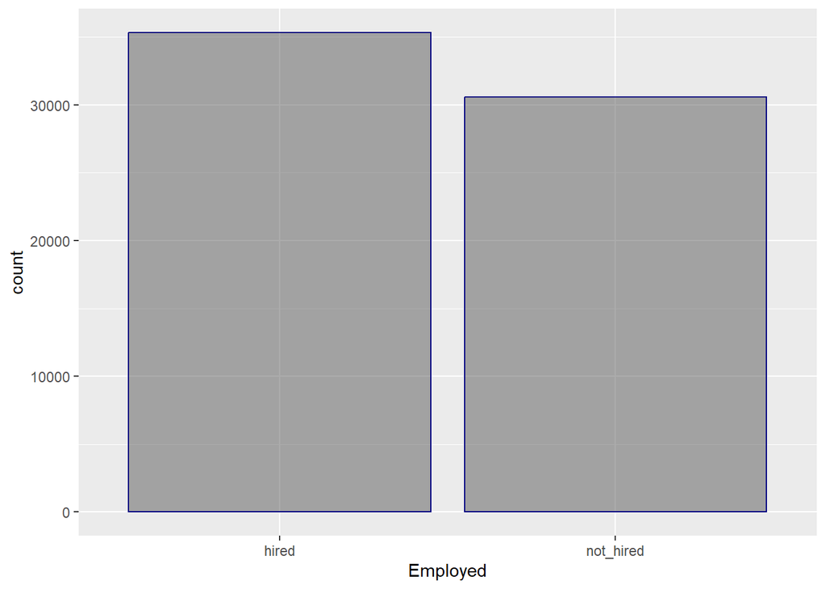

```r
ggplot(data = df_final2, aes(Employed, after_stat(count))) +
  geom_bar(alpha = 0.5, col = 'navy')
```

There’s no major imbalance.  
Finally, for the numerical variables in the train set, we want to scale them.

```r
df_final2 <- df_final2 %>%
  mutate_at(vars('YearsCode', 'YearsCodePro', 'PreviousSalary', 'ComputerSkills'), scale)
```

## 7. Model Building

We first split our dataset into train and test sets for modeling purposes.

```r
data_sample <- sample(c(TRUE, FALSE), nrow(df_final2), replace=TRUE, prob=c(0.8, 0.2))
train <- df_final2[data_sample, ]
test <- df_final2[!data_sample, ]
```

Since we do not have unbalanced data (for our target column), and we want to know the overall performance of the model, we’ll use AUC ROC as our evaluation metric.

**Logistic Regression Model:**

```r
set.seed(47)
lr_model <- glm(Employed~., data = train, family = "binomial")
summary(lr_model)
```

```
##
## Call:
## glm(formula = Employed ~ ., family = "binomial", data = train)
##
## Coefficients: (1 not defined because of singularities)
##                  Estimate Std. Error  z value Pr(>|z|)
## (Intercept)      -1.13745    0.12905   -8.814  < 2e-16 ***
## Age              -0.07645    0.03470   -2.203   0.0276 *
## Accessibility    -0.06045    0.07194   -0.840   0.4008
## EdLevel           0.07729    0.01164    6.639 3.15e-11 ***
## Employment        0.16139    0.03679    4.386 1.15e-05 ***
## MentalHealth     -0.04325    0.02796   -1.547   0.1219
## MainBranch        0.58524    0.04617   12.675  < 2e-16 ***
## YearsCode        -0.02883    0.02660   -1.084   0.2785
## YearsCodePro     -0.06758    0.02712   -2.492   0.0127 *
## PreviousSalary    0.12195    0.01262    9.665  < 2e-16 ***
## ComputerSkills   -2.09999    0.01887 -111.287  < 2e-16 ***
## Gender_Man       -0.06832    0.05357   -1.275   0.2022
## Gender_NonBinary  0.05631    0.09923    0.567   0.5704
## Gender_Woman           NA         NA       NA       NA
## ---
## Signif. codes:  0 '***' 0.001 '**' 0.01 '*' 0.05 '.' 0.1 ' ' 1
##
## (Dispersion parameter for binomial family taken to be 1)
##
##     Null deviance: 72748  on 52664  degrees of freedom
## Residual deviance: 47524  on 52652  degrees of freedom
## AIC: 47550
##
## Number of Fisher Scoring iterations: 5
```

From the p-values, we observe that `EdLevel`, `Employment`, `MainBranch`, `PreviousSalary` and `ComputerSkills` are the most important features. Let’s evaluate the model and see.

```r
pred=predict(lr_model, test, type = "response" )
# test$prob=prob
roc_lr <- roc(test$Employed, pred)
auc(roc_lr)
```

```
## Area under the curve: 0.8682
```

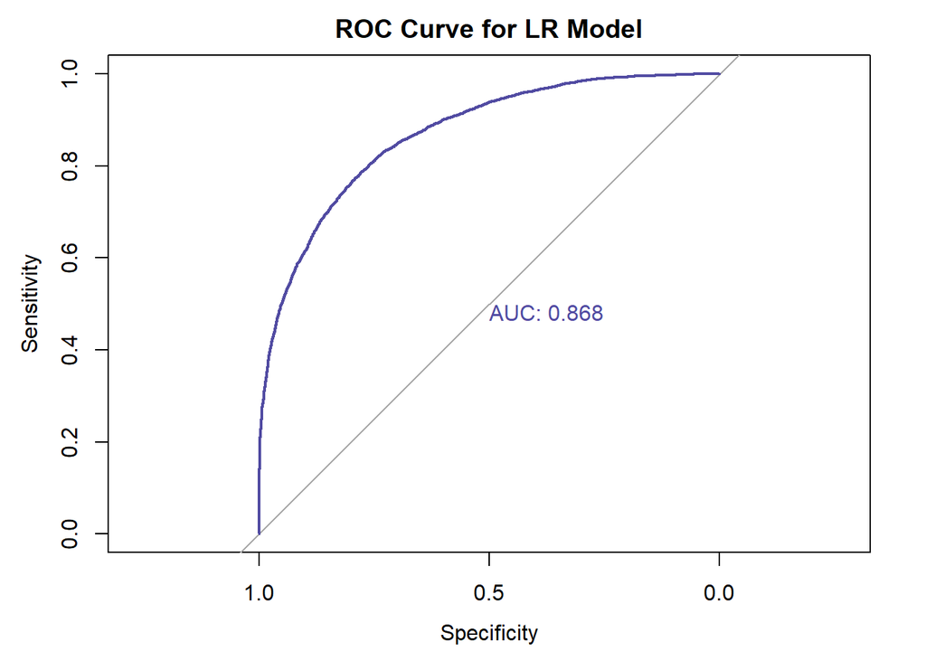

```r
plot(roc_lr, print.auc = T, main = "ROC Curve for LR Model", col = "#514BA2", lwd = 2)
```

**KNN model:**

```r
train_data <- train[, names(train) != "Employed"]
test_data <- test[, names(test) != "Employed"]
train_labels <- train$Employed

# KNN model with k = 3
k <- 3
knn_model <- class::knn(train = train_data, test = test_data, cl = train_labels, k = k, prob=TRUE)
```

```r
roc_knn <-roc(test$Employed, attributes(knn_model)$prob)
auc(roc_knn)
```

```
## Area under the curve: 0.4906
```

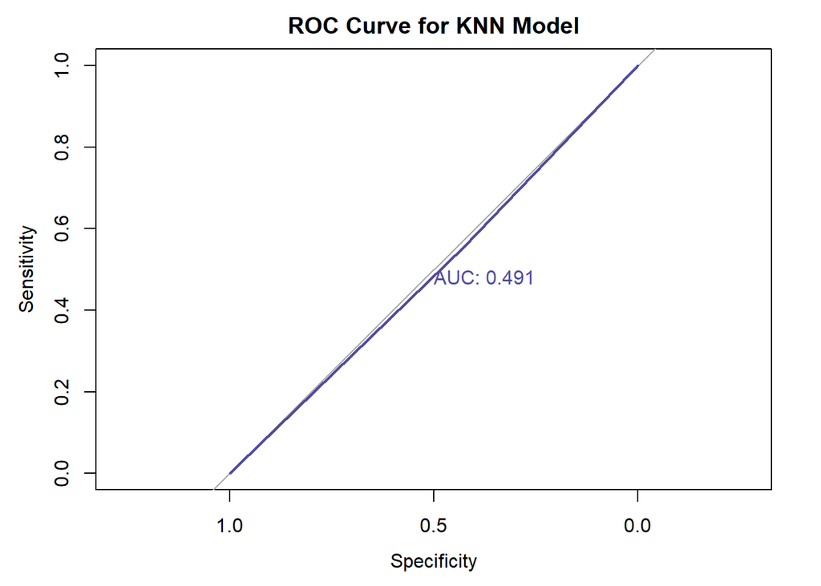

```r
plot(roc_knn, print.auc = T, main = "ROC Curve for KNN Model", col = "#514BA2", lwd = 2)
```

**SVM model:**

```r
svm_model <- svm(Employed ~ ., data = train, kernel = "linear", probability = TRUE)

# Make predictions
svm_predictions <- predict(svm_model, test, probability = TRUE)
```

```r
roc_svm <- roc(test$Employed, as.numeric(svm_predictions))
auc(roc_svm)
```

```
## Area under the curve: 0.7825
```

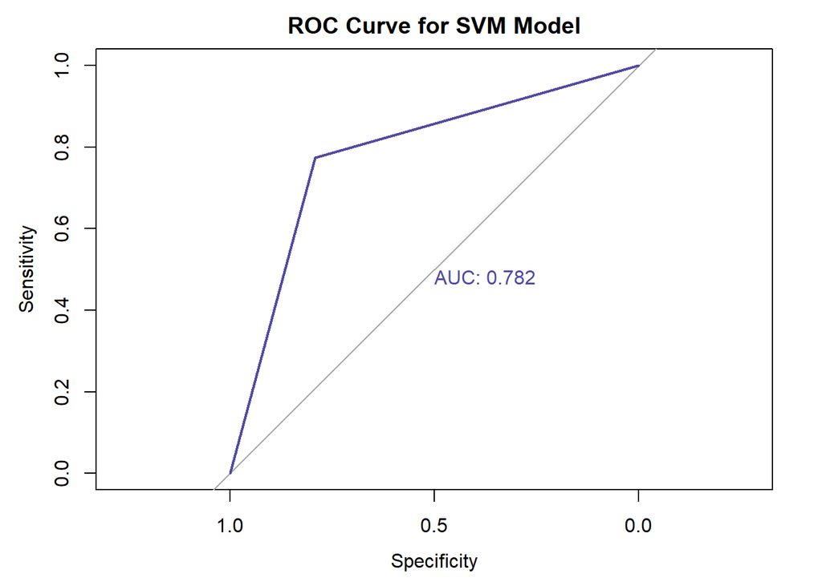

```r
plot(roc_svm, print.auc = T, main = "ROC Curve for SVM Model", col = "#514BA2", lwd = 2)
```

**Decision Tree Classifier:**

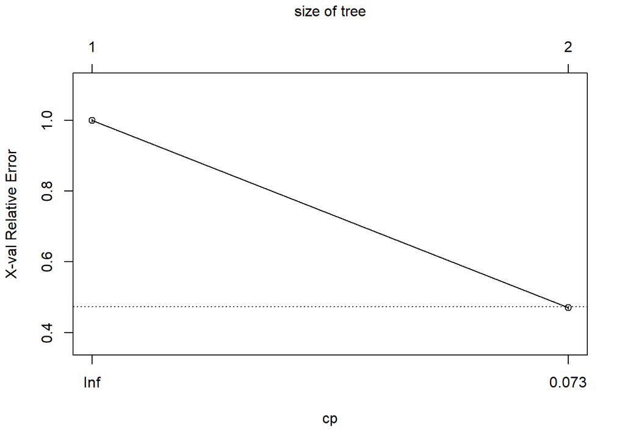

```r
set.seed(47)
dt_model <- rpart(Employed ~ ., data=df_final2)

plotcp(dt_model)
```

```r
summary(dt_model)
```

```
## Call:
## rpart(formula = Employed ~ ., data = df_final2)
##   n= 65906
##
##          CP nsplit rel error    xerror        xstd
## 1 0.5299291      0 1.0000000 1.0000000 0.004185495
## 2 0.0100000      1 0.4700709 0.4700709 0.003466203
##
## Variable importance
## ComputerSkills     MainBranch        EdLevel   Gender_Woman
##             93              3              3              1
##
## Node number 1: 65906 observations,    complexity param=0.5299291
##   predicted class=hired      expected loss=0.4641307  P(node) =1
##     class counts: 35317 30589
##    probabilities: 0.536 0.464
##   left son=2 (37238 obs) right son=3 (28668 obs)
##   Primary splits:
##       ComputerSkills < -0.2689874 to the right, improve=10299.75000, (0 missing)
##       MainBranch     < 1.5        to the left,  improve=  372.89570, (0 missing)
##       EdLevel        < 3.5        to the left,  improve=  322.47740, (0 missing)
##       Gender_Woman   < 0.5        to the left,  improve=   46.28854, (0 missing)
##       Gender_Man     < 0.5        to the right, improve=   34.66462, (0 missing)
##   Surrogate splits:
##       MainBranch   < 1.5        to the left,  agree=0.578, adj=0.031, (0 split)
##       EdLevel      < 4.5        to the left,  agree=0.577, adj=0.027, (0 split)
##       Gender_Woman < 0.5        to the left,  agree=0.568, adj=0.008, (0 split)
##       YearsCodePro < 2.371012   to the left,  agree=0.567, adj=0.004, (0 split)
##       YearsCode    < -1.229132  to the right, agree=0.567, adj=0.004, (0 split)
##
## Node number 2: 37238 observations
##   predicted class=hired      expected loss=0.2188625  P(node) =0.5650168
##     class counts: 29088  8150
##    probabilities: 0.781 0.219
##
## Node number 3: 28668 observations
##   predicted class=not_hired  expected loss=0.2172806  P(node) =0.4349832
##     class counts:  6229 22439
##    probabilities: 0.217 0.783
```

```r
printcp(dt_model)
```

```
##
## Classification tree:
## rpart(formula = Employed ~ ., data = df_final2)
##
## Variables actually used in tree construction:
## [1] ComputerSkills
##
## Root node error: 30589/65906 = 0.46413
##
## n= 65906
##
##        CP nsplit rel error  xerror      xstd
## 1 0.52993      0   1.00000 1.00000 0.0041855
## 2 0.01000      1   0.47007 0.47007 0.0034662
```

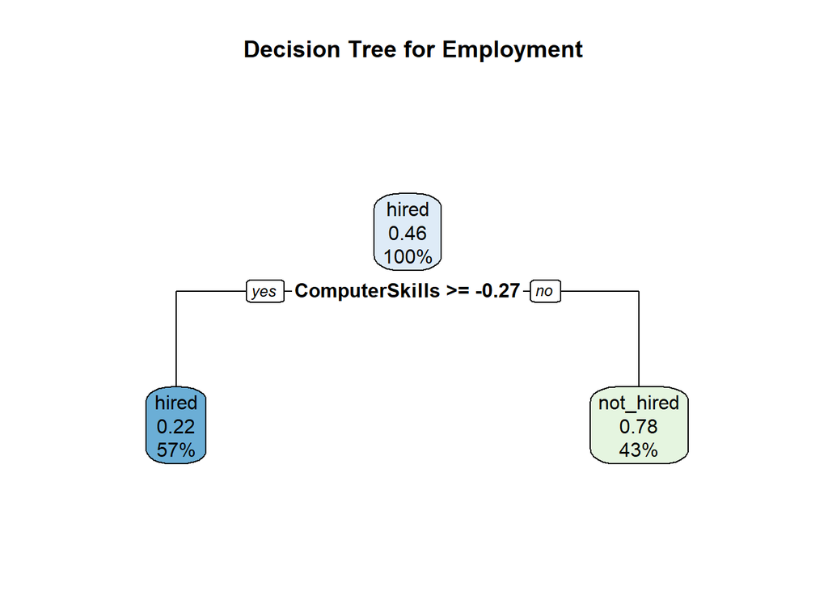

```r
# plot tree
rpart.plot(dt_model, main="Decision Tree for Employment")
```

```r
dt_pred <- predict(dt_model, test, type = 'prob')# instead of p1 dt_pred
dt_pred <- dt_pred[,2]
roc_dt <- roc(test$Employed, dt_pred)# roc_dt
auc(roc_dt)
```

```
## Area under the curve: 0.7775
```

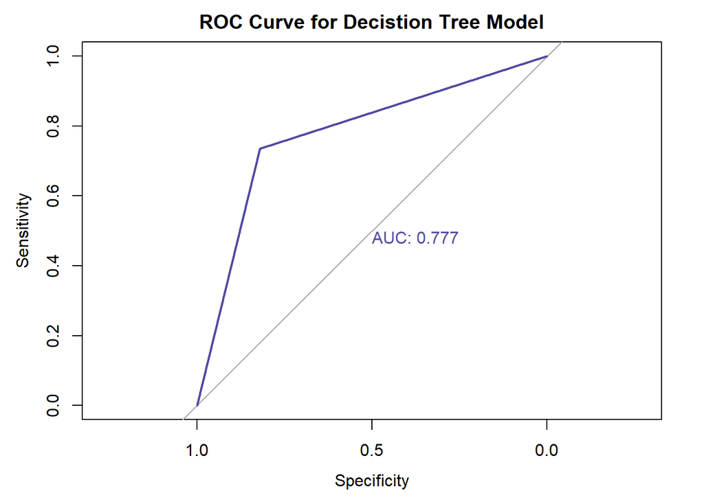

```r
plot(roc_dt, print.auc = T, main = "ROC Curve for Decistion Tree Model", col = "#514BA2", lwd = 2)
```

```r
minsplit_vals <- c(2, 3, 5, 7, 10, 12, 15, 17, 20, 23, 27, 30, 45, 50, 75, 91, 100)
max_depth_vals <- c(2, 3, 5, 7, 10, 12, 15, 17, 20, 23, 27, 30)

auc_values = c()

# Nested for loop to iterate through all combinations
for (minsplit_val in minsplit_vals) {
  for (max_depth_val in max_depth_vals) {
    dt_model_loop <- rpart(Employed ~ ., data=train, minsplit = minsplit_val, maxdepth = max_depth_val)
    p1_loop <- predict(dt_model_loop, test, type = 'prob')
    p1_loop <- p1_loop[,2]
    r_loop <- roc(test$Employed, p1_loop, percent = TRUE)
    AUC_val <- auc(r_loop)
    auc_values <- c(auc_values, AUC_val)
    print(paste('The AUC value for model with minsplit =', minsplit_val, 'and maxdepth =', max_depth_val, 'is', round(AUC_val, digits = 2), '%'))
  }
}
```

```
## [1] "The AUC value for model with minsplit = 2 and maxdepth = 2 is 77.75 %"
## [1] "The AUC value for model with minsplit = 2 and maxdepth = 3 is 77.75 %"
## [1] "The AUC value for model with minsplit = 2 and maxdepth = 5 is 77.75 %"
## [1] "The AUC value for model with minsplit = 2 and maxdepth = 7 is 77.75 %"
## [1] "The AUC value for model with minsplit = 2 and maxdepth = 10 is 77.75 %"
## [1] "The AUC value for model with minsplit = 2 and maxdepth = 12 is 77.75 %"
## [1] "The AUC value for model with minsplit = 2 and maxdepth = 15 is 77.75 %"
## [1] "The AUC value for model with minsplit = 2 and maxdepth = 17 is 77.75 %"
## [1] "The AUC value for model with minsplit = 2 and maxdepth = 20 is 77.75 %"
## [1] "The AUC value for model with minsplit = 2 and maxdepth = 23 is 77.75 %"
## [1] "The AUC value for model with minsplit = 2 and maxdepth = 27 is 77.75 %"
## [1] "The AUC value for model with minsplit = 2 and maxdepth = 30 is 77.75 %"
## [1] "The AUC value for model with minsplit = 3 and maxdepth = 2 is 77.75 %"
## [1] "The AUC value for model with minsplit = 3 and maxdepth = 3 is 77.75 %"
## [1] "The AUC value for model with minsplit = 3 and maxdepth = 5 is 77.75 %"
```

[output cut: 189 more lines]

```r
max(auc_values)
```

```
## [1] 77.74855
```

Even with hyperparameter tuning, we are getting the same AUC ROC score. Out of curiosity, let’s try a model with everything except the number of computer skills.

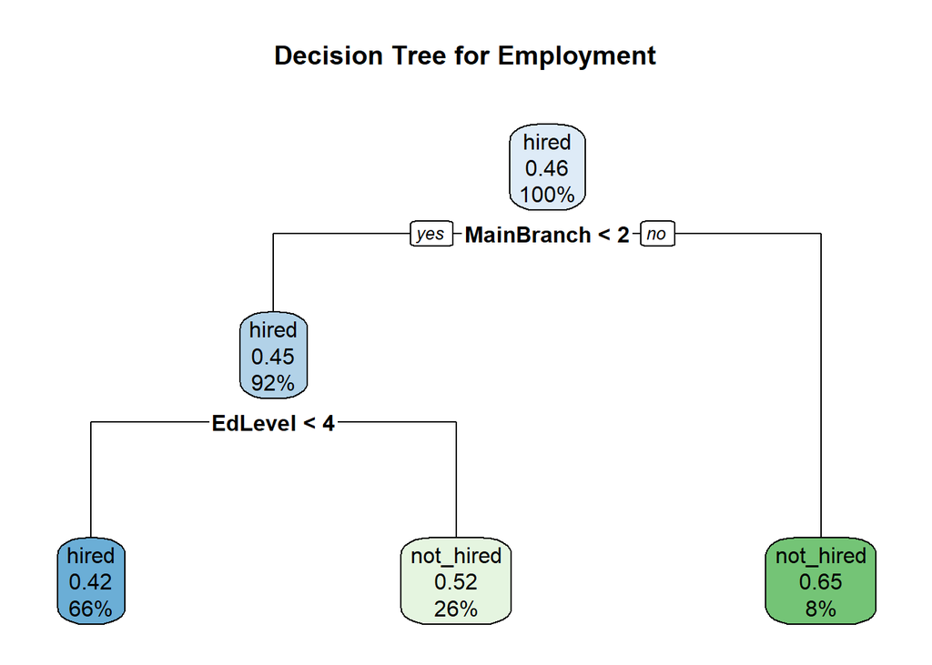

```r
dt_model_nocompskills <- rpart(Employed ~ Age + Accessibility + EdLevel + Employment + MentalHealth + MainBranch + YearsCode + YearsCodePro + PreviousSalary + Gender_Man + Gender_NonBinary + Gender_Woman, data=train)

rpart.plot(dt_model_nocompskills, main="Decision Tree for Employment")
```

```r
dt_nocs_pred <- predict(dt_model_nocompskills, test, type = 'prob')
dt_nocs_pred  <- dt_nocs_pred [,2]
r <- roc(test$Employed, dt_nocs_pred )
auc(r)
```

```
## Area under the curve: 0.5566
```

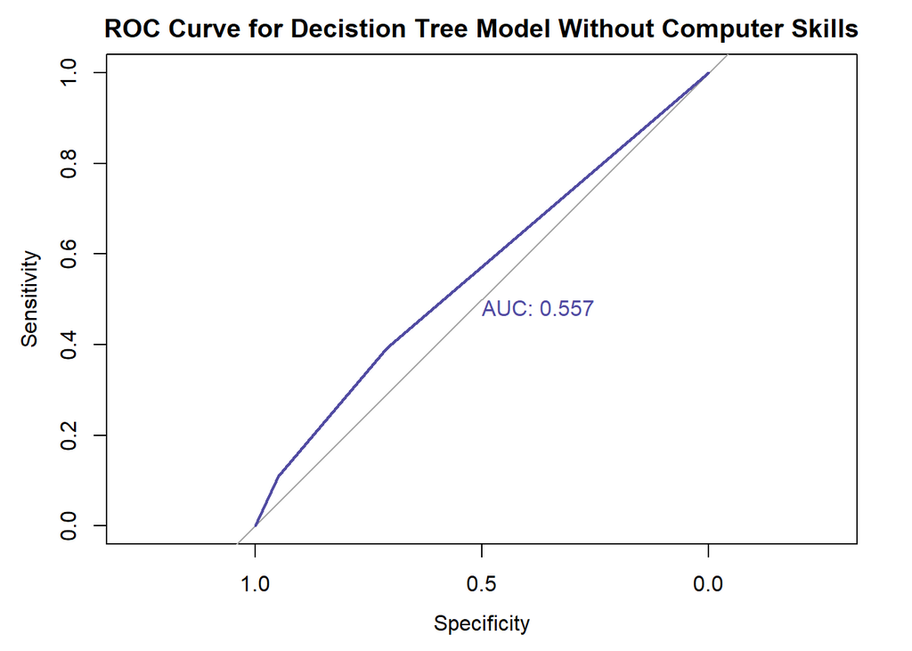

```r
plot(r, print.auc = T, main = "ROC Curve for Decistion Tree Model Without Computer Skills", col = "#514BA2", lwd = 2)
```

We conclude that our best model is the Logistic Regression model. Let’s use that to get an answer for the question:

Can we predict with at least 60% accuracy whether an individual will be employed or not, based on just their age, education level and number of skills?

```r
set.seed(47)
lr_model3 <- glm(Employed~Age +  EdLevel + ComputerSkills, data = train, family = "binomial")

pred3=predict(lr_model3, test, type = "response" )
roc_lr3 <- roc(test$Employed, pred3)
auc(roc_lr3)
```

```
## Area under the curve: 0.8666
```

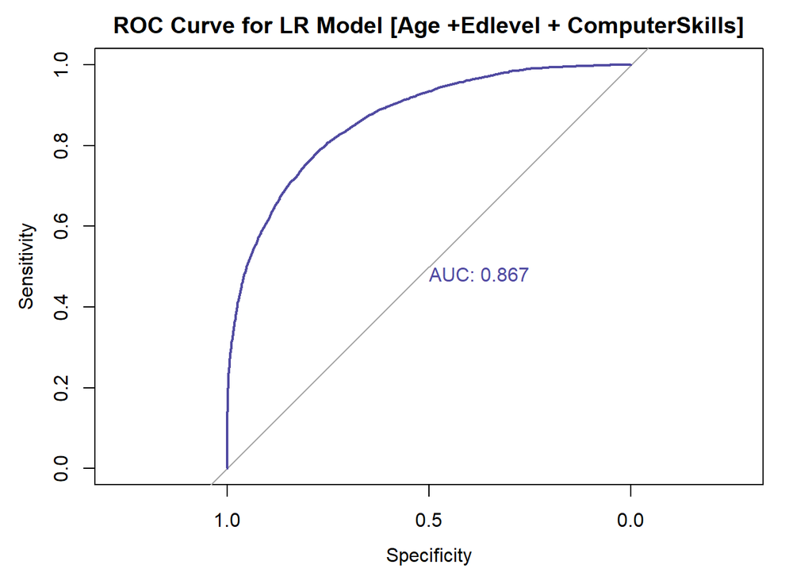

```r
plot(roc_lr3, print.auc = T, main = "ROC Curve for LR Model [Age +Edlevel + ComputerSkills]", col = "#514BA2", lwd = 2)
```

For our 4th question:

Is there a notable difference between distance based models and tree based models?

The answer is yes as we see a clear difference in the AUC ROC score of the KNN model and the Decision tree model.